# Running Basic Multilevel Models in R with `lme4`

December 08, 2018

In this workshop we will mainly run some basic multilevel models in R, and will not go through many of the background knowledge for MLM. Please check out my slides: http://marklai.netlify.com/slides/intro_mlm.html or some introductory books like [Hox et al. (2017)](https://www.amazon.com/Multilevel-Analysis-Applications-Quantitative-Methodology-ebook/dp/B075MC7XDY/ref=sr_1_1?ie=UTF8&qid=1543997640&sr=8-1&keywords=hox+multilevel+analysis) or [Snijders & Bosker (2012)](https://www.amazon.com/Multilevel-Analysis-Introduction-Advanced-Modeling/dp/184920201X/ref=sr_1_3?ie=UTF8&qid=1543997665&sr=8-3&keywords=hox+multilevel+analysis).

In R, there are many packages for multilevel modeling, two of the most common ones are the `lme4` package and the `nlme` package. In this note I will show how to run different basic multilevel models using the `lme4` package, which is newer. However, some of the models, like unstructured covariance structure, will need the `nlme` package or other packages (like the `MCMCglmm` or `brms` packages with Bayesian methods).

# 1. Importing Data Into R

We’ll import the data in .sav format.

```r
# install.packages("tidyverse")  # if you haven't installed the `tidyverse` package
library(tidyverse)
theme_set(theme_bw())  # Use a different theme for plotting with ggplot2
library(haven)
# Read in the data (pay attention to the directory)
hsball <- read_sav("../data/hsball.sav")
hsball  # print the first 10 rows
```

| id | minority | female | ses | mathach | size | sector | pracad | disclim | himinty | meanses |
| --- | --- | --- | --- | --- | --- | --- | --- | --- | --- | --- |
| 1224 | 0 | 1 | -1.528 | 5.876 | 842 | 0 | 0.35 | 1.597 | 0 | -0.428 |
| 1224 | 0 | 1 | -0.588 | 19.708 | 842 | 0 | 0.35 | 1.597 | 0 | -0.428 |
| 1224 | 0 | 0 | -0.528 | 20.349 | 842 | 0 | 0.35 | 1.597 | 0 | -0.428 |
| 1224 | 0 | 0 | -0.668 | 8.781 | 842 | 0 | 0.35 | 1.597 | 0 | -0.428 |
| 1224 | 0 | 0 | -0.158 | 17.898 | 842 | 0 | 0.35 | 1.597 | 0 | -0.428 |
| 1224 | 0 | 0 | 0.022 | 4.583 | 842 | 0 | 0.35 | 1.597 | 0 | -0.428 |
| 1224 | 0 | 1 | -0.618 | -2.832 | 842 | 0 | 0.35 | 1.597 | 0 | -0.428 |
| 1224 | 0 | 0 | -0.998 | 0.523 | 842 | 0 | 0.35 | 1.597 | 0 | -0.428 |
| 1224 | 0 | 1 | -0.888 | 1.527 | 842 | 0 | 0.35 | 1.597 | 0 | -0.428 |
| 1224 | 0 | 0 | -0.458 | 21.521 | 842 | 0 | 0.35 | 1.597 | 0 | -0.428 |

[output cut: 990 more lines]

# 2. Run the Random Intercept Model

## Model Equation

Lv-1:

$$\texttt{mathach}_{ij} = \beta_{0j} + e_{ij}$$
where $\beta_{0j}$ is the population mean math achievement of the $j$th school, and $e_{ij}$ is the level-1 random error term.

Lv-2:

$$\beta_{0j} = \gamma_{00} + u_{0j}$$
where $\gamma_{00}$ is the grand mean, and $u_{0j}$ is the deviation of the mean of the $j$th school from the grand mean.

## Running in R

First load the package:

```r
# install.packages("lme4")  # if you haven't installed the `lme4` package
# Load the `lme4` library to run MLM
library(lme4)
```

Then specify the model, following the format of `outcome ~ fixed + (random | cluster ID)`. For our data,

- the outcome variable is `mathach`,
- the fixed part is only the grand mean and we can say `1`,
- the random part is again just the mean/intercept, so `1`, and
- the cluster ID is `id`.

```r
ran_int <- lmer(mathach ~ (1 | id), data = hsball)
```

You can summarize the results using

```r
summary(ran_int)
```

```
Linear mixed model fit by REML ['lmerMod']
Formula: mathach ~ (1 | id)
   Data: hsball

REML criterion at convergence: 47116.8

Scaled residuals:
    Min      1Q  Median      3Q     Max
-3.0631 -0.7539  0.0267  0.7606  2.7426

Random effects:
 Groups   Name        Variance Std.Dev.
 id       (Intercept)  8.614   2.935
 Residual             39.148   6.257
Number of obs: 7185, groups:  id, 160

Fixed effects:
            Estimate Std. Error t value
(Intercept)  12.6370     0.2444   51.71
```

Also, you can summarize the results with the `texreg` package:

```r
texreg::screenreg(ran_int)
```

```
==================================
                     Model 1
----------------------------------
(Intercept)              12.64 ***
                         (0.24)
----------------------------------
AIC                   47122.79
BIC                   47143.43
Log Likelihood       -23558.40
Num. obs.              7185
Num. groups: id         160
Var: id (Intercept)       8.61
Var: Residual            39.15
==================================
*** p < 0.001, ** p < 0.01, * p < 0.05
```

### Plotting the random effects

You can easily plot the estimated school means (also called BLUP, best linear unbiased predictor, or the empirical Bayes estimates, which are different from the mean of the sample observations for a particular school) using the `lattice` package:

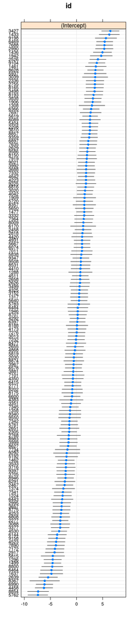

```r
library(lattice)
dotplot(ranef(ran_int, condVar = TRUE))
```